# Nig > 10 (= high Nig)

2023-10-11

## Script to work on analyses for causes paper

##Taxonomic work is needed? # Morpho differentiation types: More CS sl than CS ss overall? # Need to find expectations and test against 50:50 mark

```
##
##  Pearson's Chi-squared test with Yates' continuity correction
##
## data:  cbind(expected, observed)
## X-squared = 27.212, df = 1, p-value = 1.823e-07
```

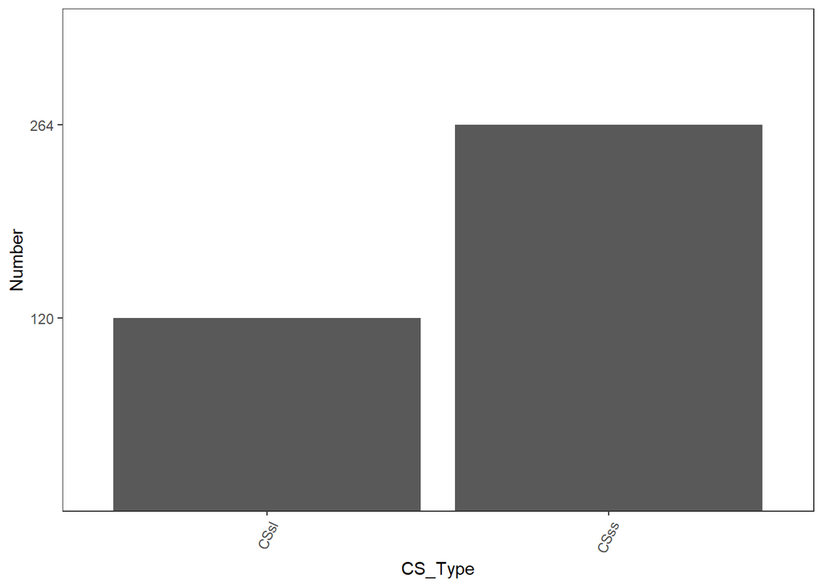

More CSss than the 50% benchmark (significant), so reject the idea that most CS are just due to taxonomic oversight.

# Available technology – More diagnostic differences in species described earlier?

```
##
##        FALSE TRUE
##   1750     3   16
##   1760     3    7
##   1770     1    6
##   1780     2    5
##   1790     1    9
##   1800     7    4
##   1810     3    6
##   1820     9   13
##   1830     8   14
##   1840     6   16
##   1850     5    8
##   1860    10   11
##   1870     5   11
##   1880     7    5
##   1890     2    7
##   1900     1   10
##   1910     2    3
##   1920     3    2
##   1930     4    5
##   1940     1    1
##   1950     1    5
##   1960     2    3
##   1970     3    3
##   1980     2    6
##   1990     3    5
##   2000     4   14
##   2010     9   16
```

```
##
##  Pearson's Chi-squared test
##
## data:  decademorpho$decade and decademorpho$CSss
## X-squared = 26.118, df = 26, p-value = 0.4566
```

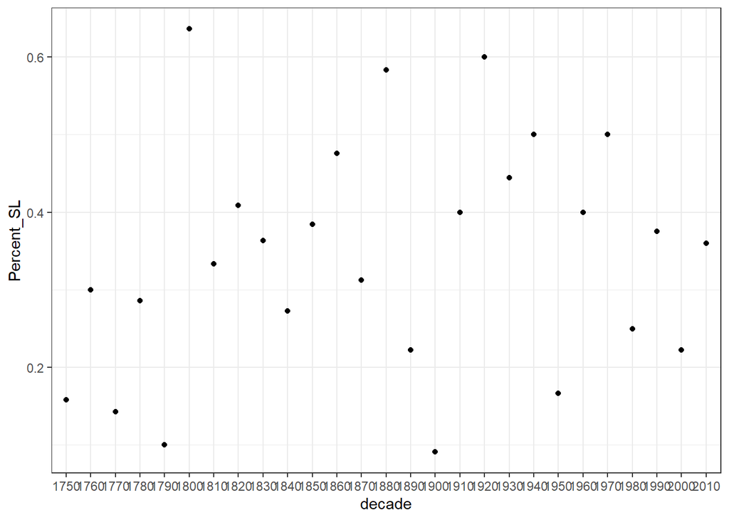

There is no trend in the percent of CSsl (diagnostic differences) through time; hypothesis not supported.

# Prevailing theories of nature and species origins - More CS in fragmented habitats in species described before Darwin?

```
##
##              1 10 100 1000 25  5
##   1756-1859  2 93  19   52 67 54
##   1860-1980  2 61  19   35 59 28
##   1981-2020  1 34  13    8 19 12
```

```
##
##  Pearson's Chi-squared test
##
## data:  breaks_HKK$decade_bin and breaks_HKK$HKK
## X-squared = 14.641, df = 10, p-value = 0.1457
```

```
##                      1        10        100       1000        25         5
## pre_Darwin 0.006968641 0.3240418 0.06620209 0.18118467 0.2334495 0.1881533
## pre_Kimura 0.009803922 0.2990196 0.09313725 0.17156863 0.2892157 0.1372549
## modern     0.011494253 0.3908046 0.14942529 0.09195402 0.2183908 0.1379310
```

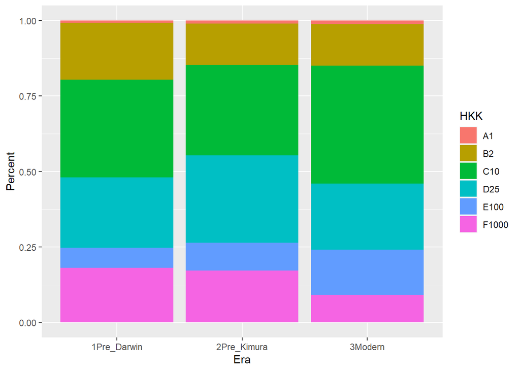

NOT SIGNIFICANT with this data subset.

# Accessibility of habitat when species described - Percentage of CS in inaccessible habitats higher in earlier spp?

```
##
##        Difficult Easy Normal
##   1750         4    8     30
##   1760         1    4      9
##   1770         2    4      7
##   1780         1    1     10
##   1790         1    6     13
##   1800         2    5     13
##   1810         2    2     12
##   1820         3    7     30
##   1830         4   13     28
##   1840         2    8     46
##   1850         0    7     29
##   1860         1   12     31
##   1870         5    2     26
##   1880         5    1     29
##   1890         0    4     15
##   1900         1    2     16
##   1910         5    1      6
##   1920         0    1     11
##   1930         1    2     11
##   1940         0    0      4
##   1950         2    1      8
##   1960         0    1      8
##   1970         2    4      5
##   1980         8    1      6
##   1990         2    1     12
##   2000         4    9     23
##   2010         3    6     25
```

```
##
##  Pearson's Chi-squared test
##
## data:  decadeAccess$decade and decadeAccess$Access
## X-squared = 97.815, df = 52, p-value = 0.0001254
```

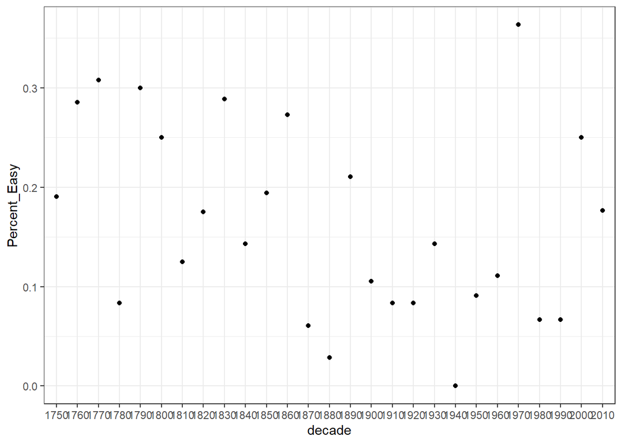

Hypothesis not supported. DIFFERENT FROM ALL SPECIES DATA but same as RIOK. Double check to see when I’m comparing all access categories vs just percent easy, but either way we don’t see clear support. (Just need to be sure when reporting p-values.)

## In sum, when we only look at species with CS (i.e. our database), the effect of taxonomic work goes away. This is interesting since that was the strongest effect in paper 1. THIS IS STILL TRUE WITH Nig > 10.

## Effect of recent divergence - dispersal

# Larval type – Planktotrophic/pelagic larvae leads to less CS/NS)?

Note1: for this I’m working with a separate surveylarv input file where I have corrected larval types to pt, lt, dd, and removed all others, including cases where there are multiple types checked. (Most of those cases are where the two CS have different larvae.) This left 473 CS with larval info.

Note2: the data fail the homoscedasticity test (Bartlett’s) so I’ve used a nonparametric Kruskal-Wallis test to see if CS/NS is different among groups.

```
##        1        2        3
## 3.741935 3.441176 3.242915
```

```
##        1        2        3
## 2.572117 3.241359 3.381817
```

```
##
##  Kruskal-Wallis rank sum test
##
## data:  as.numeric(larv_NbCS$Nb_CS) and larv_NbCS$Larv_type
## Kruskal-Wallis chi-squared = 9.6626, df = 2, p-value = 0.007976
```

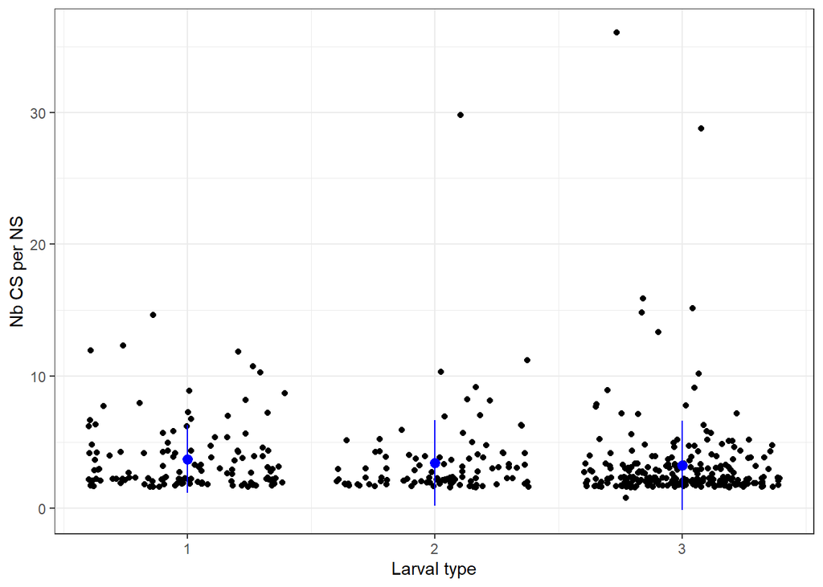

Hypothesis supported, with DD having higher mean CS per nominal species. This is the same as all species AND when NbCS per article = 1. In this graph it shows that although means aren’t very different, lots more planktonic species have very low Nb per CS, which may be driving the differences.

# High HKK leads to more CS ss – testing this based on Nb_CS per HKK.

Note: data again failed homoscedasticity, using Kruskal Wallis test

```
##        1        5       10       25      100     1000
## 3.888889 3.355932 3.630332 3.082803 3.169492 3.566372
```

```
##        1        5       10       25      100     1000
## 2.891559 2.189819 3.236081 2.684146 1.763153 3.995256
```

```
##
##  Kruskal-Wallis rank sum test
##
## data:  HKK_NbCS$Nb_CS and HKK_NbCS$HKKv3
## Kruskal-Wallis chi-squared = 5.7848, df = 5, p-value = 0.3277
```

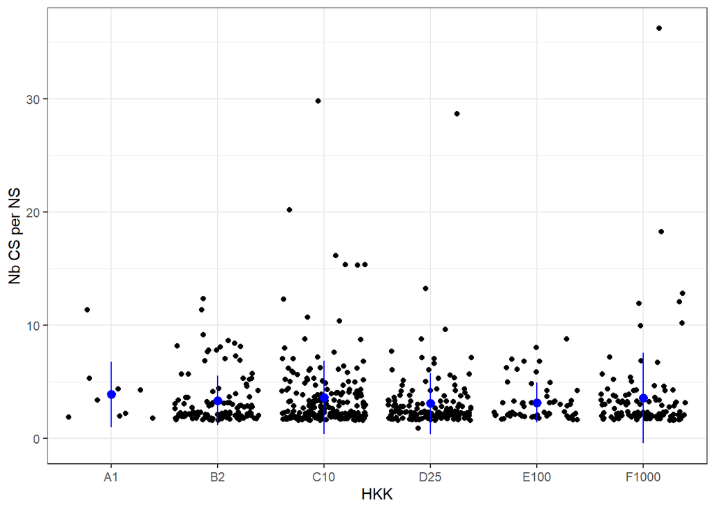

Result: Ok, this looks like the whole dataset again. No clear / significant trend.

## In sum, again the support for the role of recent divergence as measured by a proxy of dispersal depends on what the proxy is. Support with larval type, not with HKK. Same as all_species dataset.

# More stable environments = more CSss or statistical differences

Note: stable = pelagic, deepsea, cave, coralreef; not stable = coastal, intertidal, estuarine, seagrass

```
##
##         FALSE TRUE
##   FALSE    80   40
##   TRUE    153  111
```

```
##
##  Pearson's Chi-squared test with Yates' continuity correction
##
## data:  stable_hab$CSss and stable_hab$Stable
## X-squared = 2.272, df = 1, p-value = 0.1317
```

```
##                FALSE      TRUE
## CSss_total 0.6566524 0.7350993
## CSsl_total 0.3433476 0.2649007
```

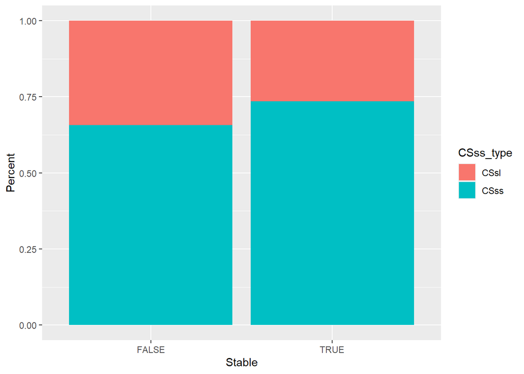

# Note also that stabilizing selection predicts more CSss than CSsl, which is what we find (see above).

## In sum, support for this idea is mixed with this datasubset. Different from RIOK, alldata, or NbCS per article = 1.

## High Ne (neutral hypotheses)

# Reproductive investment - Low reproductive investment leads to more statistical divergence? (Repro. investment proxy for Ne)

```
##
##                      HIGH LOW
##   Diagnostic           38  39
##   No differentiation   32  43
##   Statistic            43  54
```

```
##
##  Pearson's Chi-squared test
##
## data:  surveylarv$Morpho_diff and surveylarv$Repro_invest
## X-squared = 0.75569, df = 2, p-value = 0.6853
```

Result: not significant.

# High HKK leads to more CS ss (HKK as proxy for Ne)

```
##
##                       1  5 10 25 100 1000
##   Diagnostic          4 24 36 36   7    6
##   No differentiation  1 18 33 22  11    9
##   Statistic           0 28 49 25  10   29
```

```
##              1         5        10        25       100      1000
## stat_total 0.0 0.4000000 0.4152542 0.3012048 0.3571429 0.6590909
## diag_total 0.8 0.3428571 0.3050847 0.4337349 0.2500000 0.1363636
## nod_total  0.2 0.2571429 0.2796610 0.2650602 0.3928571 0.2045455
```

```
##
##    1    5   10   25  100 1000
##    5   70  118   83   28   44
```

```
##
##  Pearson's Chi-squared test
##
## data:  surveymorpho$Morpho_diff and surveymorpho$HKKv3
## X-squared = 25.896, df = 10, p-value = 0.003883
```

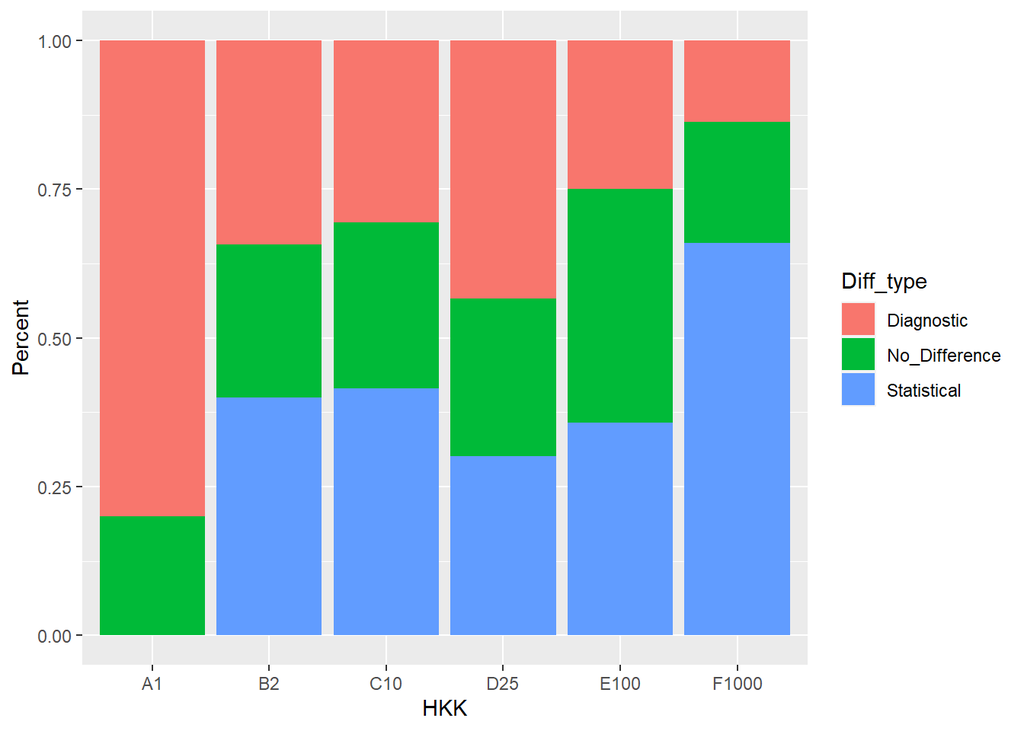

```
##
##        FALSE TRUE
##   1        4    1
##   5       24   46
##   10      36   82
##   25      36   47
##   100      7   21
##   1000     6   38
```

```
##
##  Pearson's Chi-squared test
##
## data:  surveymorpho$HKKv3 and surveymorpho$CSss
## X-squared = 17.794, df = 5, p-value = 0.003216
```

```
##              1         5        10        25  100      1000
## CSss_total 0.2 0.6571429 0.6949153 0.5662651 0.75 0.8636364
## CSsl_total 0.8 0.3428571 0.3050847 0.4337349 0.25 0.1363636
```

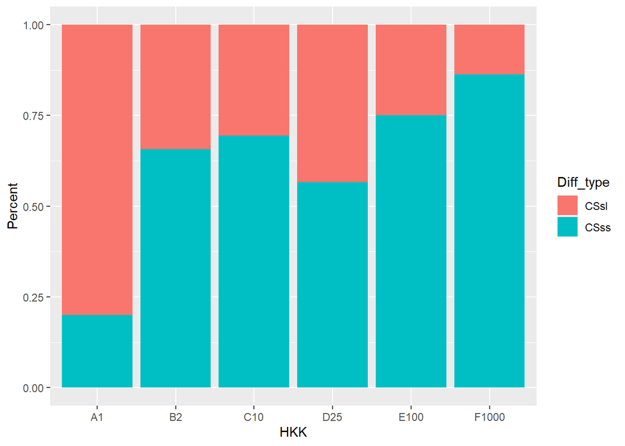

Results: More diagnostic differences (=CSsl) at lower HKK values, both when considering 3 morpho classes AND just ss vs sl. Overall p-value still significant. Lots more CSss at high HKK.

## In sum, we see support for the neutral hypothesis if we use HKK as a proxy for Ne but NOT if we use reproductive investment.

## Hypothesis: effect of recent divergence – More sympatric than allopatric CS/NS for a given Nsg?

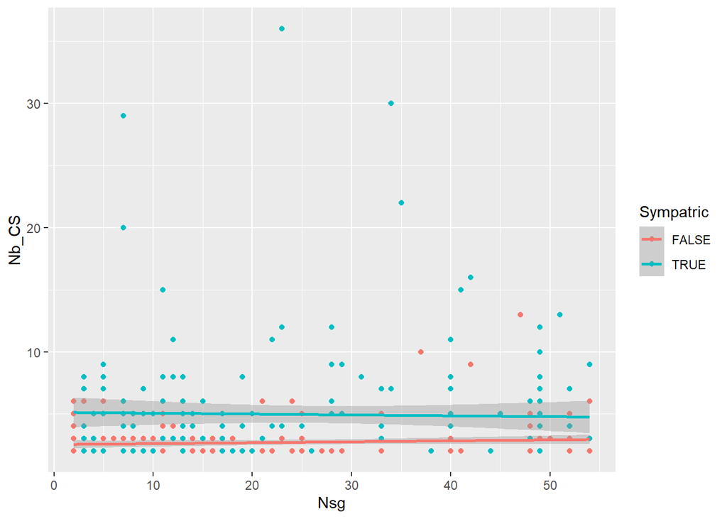

```
## ANOVA Table (type II tests)
##
##      Effect DFn DFd     F     p p<.05      ges
## 1     Nb_CS   1 391 0.009 0.925       2.29e-05
## 2 Sympatric   1 391 0.961 0.328       2.00e-03
```

These results aren’t statistically significant (ANCOVA) but the graph is in line with the hypothesis. Marginal support. HOWEVER these lines look closer together than the whole dataset? Careful on interpretation.

## Selection against hybrids – More diagnostic differences in sympatry than allopatry?

```
##
##         FALSE TRUE
##   FALSE    57   30
##   TRUE     86   77
```

```
##
##  Pearson's Chi-squared test with Yates' continuity correction
##
## data:  surveymorpho$CSss and surveymorpho$Sympatric
## X-squared = 3.2674, df = 1, p-value = 0.07067
```

```
##                FALSE      TRUE
## CSss_total 0.6013986 0.7196262
## CSsl_total 0.3986014 0.2803738
```

[figure not shown]

## Importance of biological traits

# More diagnostic traits with hard skeleton?

```
##
##                        N   Y
##   Diagnostic          28  87
##   No differentiation  33  71
##   Statistic           36 107
```

```
##
##  Pearson's Chi-squared test
##
## data:  surveymorpho$Morpho_diff and surveymorpho$hard_skeleton
## X-squared = 1.8341, df = 2, p-value = 0.3997
```

```
##                    N         Y
## stat_total 0.3711340 0.4037736
## diag_total 0.2886598 0.3283019
## nod_total  0.3402062 0.2679245
```

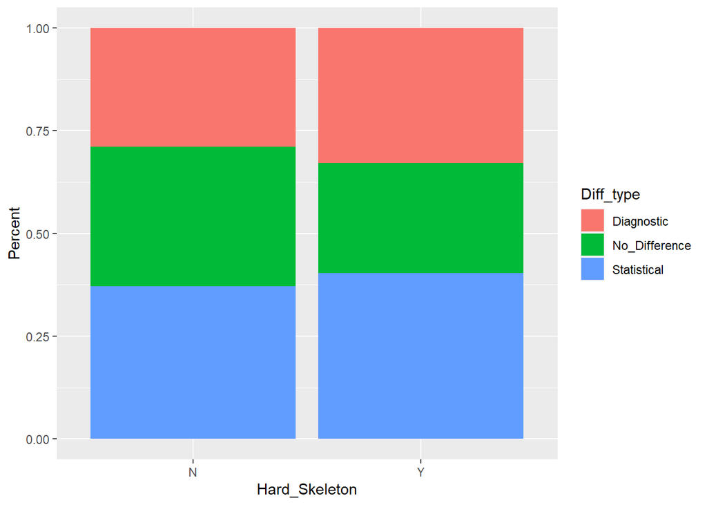

THIS IS NO LONGER SUPPORTED WHEN Nig > 10. This must mean that species that were dropped in some way affected this. Investigate!

# More diagnostic traits with image vision?

```
##
##                       N  Y
##   Diagnostic         53 62
##   No differentiation 60 44
##   Statistic          65 78
```

```
##
##  Pearson's Chi-squared test
##
## data:  surveymorpho$Morpho_diff and surveymorpho$image
## X-squared = 4.2494, df = 2, p-value = 0.1195
```

Result: hypothesis not supported

# More diagnostic traits with internal fertilization?

```
##
##                       B  E  I
##   Diagnostic         40 45 30
##   No differentiation 33 51 20
##   Statistic          32 76 35
```

```
##
##  Pearson's Chi-squared test
##
## data:  surveymorpho$Morpho_diff and surveymorpho$ferti
## X-squared = 7.6551, df = 4, p-value = 0.1051
```

```
##                    B         E         I
## stat_total 0.3047619 0.4418605 0.4117647
## diag_total 0.3809524 0.2616279 0.3529412
## nod_total  0.3142857 0.2965116 0.2352941
```

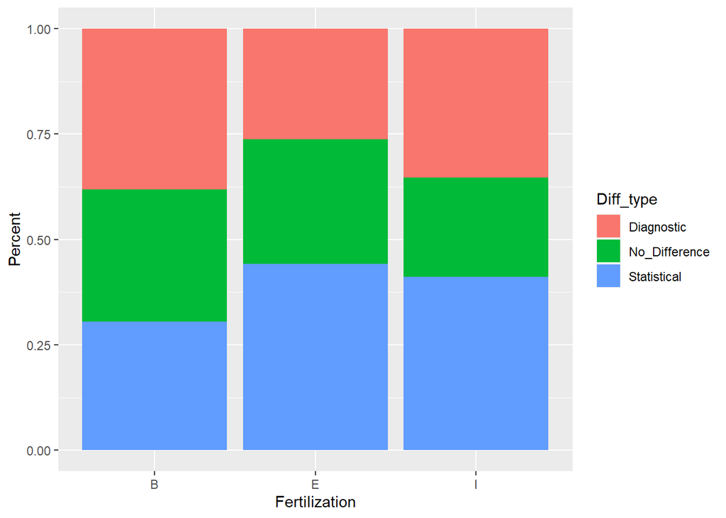

Result: hypothesis NOT supported with this dataset! Different from all other subsets of data.

# More diagnostic traits with external genitalia?

```
##
##                       B  N  Y
##   Diagnostic         24 63 28
##   No differentiation 18 69 17
##   Statistic          14 95 34
```

```
##
##  Pearson's Chi-squared test
##
## data:  surveymorpho$Morpho_diff and surveymorpho$genitals
## X-squared = 9.0799, df = 4, p-value = 0.05913
```

```
##                    B         N         Y
## stat_total 0.2500000 0.4185022 0.4303797
## diag_total 0.4285714 0.2775330 0.3544304
## nod_total  0.3214286 0.3039648 0.2151899
```

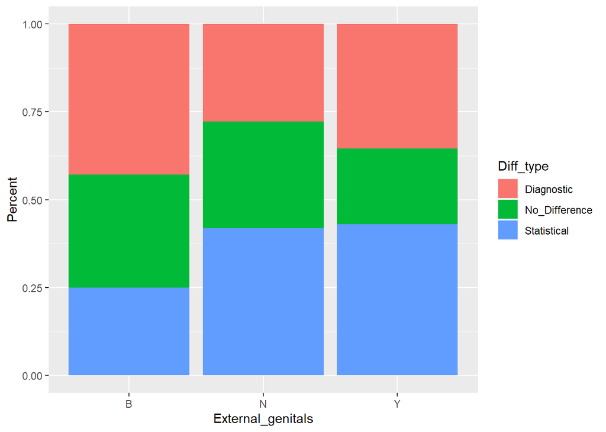

Result: more diagnostic traits with external, but this is MARGINAL and seems to go away when gastropods are removed (double-check). Hypothesis supported, but less than with other subsets.

## In sum, biological traits are much less important with this dataset. Who was removed?? Need to look into this.

## So, overall conclusions: When looking at the full dataset, there is support for several (but not all) sets of hypotheses. Interestingly, the effect of taxonomic work/effort seems to go away, while the effect of taxonomic class remains. Some support for both selection-based and neutral ideas.

## When considering Nig > 10, there is much less support for biological factors here. Need to figure out which cases were dropped.